# Construcción y cálculo del IMTM

# Objetivo 1:

Para *Caracterizar la madurez digital de los municipios de la región del Biobio al año 2022 según el Índice de madurez tecnológica Municipal* se construirán dataframes para luego realizar tablas con los valores obtenidos en cada dimensión, correlaciones entre dimensión e índice, estadística descriptiva y por último gráficos de caja que permitan apreciar la distribución de estos valores.

```r
# Crear dataframes de las dimensiones
  IT <- select(cuestionarios, Municipio, seg_info, num_serv, IT)
  RRHH <- select(cuestionarios, Municipio, area_info, educ_info, org_info, RRHH)
  GTM <- select(cuestionarios, Municipio, intranet, procesos, estrategia_servicios, GTM)
  SML <- select(cuestionarios, Municipio, tramites, SML)
```

```r
  kable(IT, digits= 2, caption = "IT Region del Biobío", align = 'r',
        col.names = c("Municipalidades", "Medidas seguridad", "Numero de servidores", "IT"))
```

IT Region del Biobío

| Municipalidades | Medidas seguridad | Numero de servidores | IT |
| --- | --- | --- | --- |
| Chiguayante | 1.00 | 0.26 | 0.63 |
| Concepción | 1.00 | 0.13 | 0.56 |
| Coronel | 1.00 | 0.40 | 0.70 |
| Florida | 0.75 | 0.13 | 0.44 |
| Hualpén | 1.00 | 0.00 | 0.50 |
| Hualqui | 0.25 | 0.06 | 0.16 |
| Lota | 1.00 | 0.00 | 0.50 |
| Penco | 1.00 | 0.13 | 0.56 |
| San Pedro de la Paz | 0.75 | 0.06 | 0.41 |
| Santa Juana | 1.00 | 0.06 | 0.53 |
| Talcahuano | 1.00 | 0.66 | 0.83 |
| Tomé | 1.00 | 0.20 | 0.60 |
| Alto Biobío | 0.50 | 0.06 | 0.28 |
| Antuco | 0.00 | 0.00 | 0.00 |
| Cabrero | 1.00 | 0.26 | 0.63 |
| Laja | 0.75 | 0.06 | 0.41 |
| Los Ángeles | 1.00 | 0.40 | 0.70 |
| Mulchén | 1.00 | 0.00 | 0.50 |
| Nacimiento | 1.00 | 0.20 | 0.60 |
| Negrete | 0.00 | 0.06 | 0.03 |
| Quilaco | 0.25 | 0.13 | 0.19 |
| Quilleco | 0.75 | 0.20 | 0.48 |
| San Rosendo | 0.25 | 0.06 | 0.16 |
| Santa Barbara | 0.75 | 0.26 | 0.50 |
| Tucapel | 0.75 | 0.13 | 0.44 |
| Yumbel | 0.50 | 0.13 | 0.32 |
| Arauco | 0.50 | 0.06 | 0.28 |
| Cañete | 0.75 | 0.06 | 0.41 |
| Contulmo | 0.50 | 0.00 | 0.25 |
| Curanilahue | 0.50 | 0.20 | 0.35 |
| Lebu | 1.00 | 0.13 | 0.56 |
| Los Álamos | 0.75 | 0.06 | 0.41 |
| Tirúa | 0.00 | 0.00 | 0.00 |

```r
# Dataframe RRHH
  kable(RRHH, digits = 2, caption = "RRHH Region del Biobío", align = 'r',
        col.names = c("Municipalidades", "Area informática",
        "Nivel educacional encargado", "Area dependencia", "RRHH"))
```

RRHH Region del Biobío

| Municipalidades | Area informática | Nivel educacional encargado | Area dependencia | RRHH |
| --- | --- | --- | --- | --- |
| Chiguayante | 1 | 1.0 | 1.0 | 1.00 |
| Concepción | 1 | 1.0 | 1.0 | 1.00 |
| Coronel | 1 | 1.0 | 1.0 | 1.00 |
| Florida | 0 | 1.0 | 1.0 | 0.67 |
| Hualpén | 1 | 1.0 | 1.0 | 1.00 |
| Hualqui | 1 | 0.5 | 1.0 | 0.83 |
| Lota | 1 | 1.0 | 0.4 | 0.80 |
| Penco | 1 | 1.0 | 1.0 | 1.00 |
| San Pedro de la Paz | 1 | 1.0 | 0.4 | 0.80 |
| Santa Juana | 1 | 1.0 | 0.6 | 0.87 |
| Talcahuano | 1 | 1.0 | 0.6 | 0.87 |
| Tomé | 1 | 0.5 | 0.4 | 0.63 |
| Alto Biobío | 0 | 0.5 | 1.0 | 0.50 |
| Antuco | 0 | 1.0 | 1.0 | 0.67 |
| Cabrero | 0 | 1.0 | 0.6 | 0.53 |
| Laja | 1 | 0.5 | 1.0 | 0.83 |
| Los Ángeles | 1 | 0.5 | 1.0 | 0.83 |
| Mulchén | 1 | 1.0 | 0.6 | 0.87 |
| Nacimiento | 1 | 1.0 | 1.0 | 1.00 |
| Negrete | 0 | 0.5 | 0.2 | 0.23 |
| Quilaco | 1 | 0.5 | 0.2 | 0.57 |
| Quilleco | 1 | 1.0 | 0.2 | 0.73 |
| San Rosendo | 0 | 0.5 | 1.0 | 0.50 |
| Santa Barbara | 1 | 1.0 | 1.0 | 1.00 |
| Tucapel | 1 | 1.0 | 0.2 | 0.73 |
| Yumbel | 0 | 1.0 | 0.6 | 0.53 |
| Arauco | 1 | 0.5 | 0.6 | 0.70 |
| Cañete | 0 | 0.5 | 1.0 | 0.50 |
| Contulmo | 1 | 1.0 | 0.6 | 0.87 |
| Curanilahue | 1 | 1.0 | 0.4 | 0.80 |
| Lebu | 1 | 1.0 | 0.2 | 0.73 |
| Los Álamos | 1 | 0.5 | 0.2 | 0.57 |
| Tirúa | 0 | 1.0 | 1.0 | 0.67 |

```r
# Dataframe GTM
  kable(GTM, digits= 2, caption = "GTM Region del Biobío", align = 'r',
        col.names = c("Municipalidades", "Intranet",
        "Informatización procesos internos", "Estrategia a ciudadanos", "GTM"))
```

GTM Region del Biobío

| Municipalidades | Intranet | Informatización procesos internos | Estrategia a ciudadanos | GTM |
| --- | --- | --- | --- | --- |
| Chiguayante | 1 | 1.00 | 1 | 1.00 |
| Concepción | 1 | 0.94 | 1 | 0.98 |
| Coronel | 0 | 0.83 | 0 | 0.28 |
| Florida | 0 | 0.89 | 1 | 0.63 |
| Hualpén | 1 | 0.94 | 1 | 0.98 |
| Hualqui | 1 | 0.94 | 0 | 0.65 |
| Lota | 0 | 0.33 | 0 | 0.11 |
| Penco | 0 | 0.33 | 1 | 0.44 |
| San Pedro de la Paz | 1 | 0.89 | 1 | 0.96 |
| Santa Juana | 1 | 0.56 | 0 | 0.52 |
| Talcahuano | 1 | 0.89 | 0 | 0.63 |
| Tomé | 1 | 0.94 | 1 | 0.98 |
| Alto Biobío | 0 | 0.50 | 0 | 0.17 |
| Antuco | 1 | 0.50 | 0 | 0.50 |
| Cabrero | 0 | 0.39 | 0 | 0.13 |
| Laja | 1 | 0.78 | 0 | 0.59 |
| Los Ángeles | 1 | 0.72 | 0 | 0.57 |
| Mulchén | 1 | 0.61 | 0 | 0.54 |
| Nacimiento | 0 | 0.94 | 0 | 0.31 |
| Negrete | 0 | 0.61 | 0 | 0.20 |
| Quilaco | 0 | 0.44 | 0 | 0.15 |
| Quilleco | 1 | 0.72 | 1 | 0.91 |
| San Rosendo | 1 | 0.00 | 0 | 0.33 |
| Santa Barbara | 1 | 0.67 | 0 | 0.56 |
| Tucapel | 1 | 0.67 | 0 | 0.56 |
| Yumbel | 0 | 0.50 | 0 | 0.17 |
| Arauco | 0 | 0.44 | 0 | 0.15 |
| Cañete | 0 | 0.39 | 0 | 0.13 |
| Contulmo | 0 | 0.50 | 0 | 0.17 |
| Curanilahue | 1 | 0.39 | 0 | 0.46 |
| Lebu | 0 | 0.50 | 0 | 0.17 |
| Los Álamos | 0 | 0.94 | 1 | 0.65 |
| Tirúa | 0 | 0.50 | 1 | 0.50 |

```r
# Dimensión SML
  kable(SML, digits= 2, caption = "SML Region del Biobío", align = 'r',
        col.names = c("Municipalidades", "Digitalización trámites", "SML"))
```

SML Region del Biobío

| Municipalidades | Digitalización trámites | SML |
| --- | --- | --- |
| Chiguayante | 0.28 | 0.28 |
| Concepción | 1.00 | 1.00 |
| Coronel | 0.56 | 0.56 |
| Florida | 0.06 | 0.06 |
| Hualpén | 0.78 | 0.78 |
| Hualqui | 0.06 | 0.06 |
| Lota | 0.17 | 0.17 |
| Penco | 0.00 | 0.00 |
| San Pedro de la Paz | 1.00 | 1.00 |
| Santa Juana | 0.28 | 0.28 |
| Talcahuano | 0.61 | 0.61 |
| Tomé | 0.28 | 0.28 |
| Alto Biobío | 0.11 | 0.11 |
| Antuco | 0.06 | 0.06 |
| Cabrero | 0.06 | 0.06 |
| Laja | 0.11 | 0.11 |
| Los Ángeles | 1.00 | 1.00 |
| Mulchén | 0.33 | 0.33 |
| Nacimiento | 0.67 | 0.67 |
| Negrete | 0.33 | 0.33 |
| Quilaco | 0.06 | 0.06 |
| Quilleco | 0.17 | 0.17 |
| San Rosendo | 0.06 | 0.06 |
| Santa Barbara | 0.17 | 0.17 |
| Tucapel | 0.06 | 0.06 |
| Yumbel | 0.00 | 0.00 |
| Arauco | 0.11 | 0.11 |
| Cañete | 0.22 | 0.22 |
| Contulmo | 0.06 | 0.06 |
| Curanilahue | 0.06 | 0.06 |
| Lebu | 0.11 | 0.11 |
| Los Álamos | 0.50 | 0.50 |
| Tirúa | 0.17 | 0.17 |

## Estadística descriptiva Dimensiones

```r
# Aplicar la función stats_descr a todas las dimensiones
  Descr_IT <- stats_descr(cuestionarios$IT)
  Descr_RRHH <- stats_descr(cuestionarios$RRHH)
  Descr_GTM <- stats_descr(cuestionarios$GTM)
  Descr_SML <- stats_descr(cuestionarios$SML)
```

```r
# Creación Dataframe estadísticos descriptivos por dimensión
  Caracterizar <- data.frame(Descr_IT, Descr_RRHH, Descr_GTM, Descr_SML)
  kable(Caracterizar, digits = 2, align = 'r', caption =
          "Estadística descriptiva Dimensiones IMTM 2022 Región del Biobío",
          col.names = c("IT", "RRHH", "GTM","SML"))
```

Estadística descriptiva Dimensiones IMTM 2022 Región del Biobío

|  | IT | RRHH | GTM | SML |
| --- | --- | --- | --- | --- |
| Mínimo | 0.00 | 0.23 | 0.11 | 0.00 |
| Primer_Cuartil.25% | 0.28 | 0.63 | 0.17 | 0.06 |
| Media | 0.42 | 0.75 | 0.49 | 0.29 |
| Máximo | 0.83 | 1.00 | 1.00 | 1.00 |
| Mediana | 0.44 | 0.80 | 0.50 | 0.17 |
| Variación | 0.04 | 0.04 | 0.09 | 0.09 |
| Desviación_estandar | 0.21 | 0.19 | 0.29 | 0.30 |
| Tercer_Cuartil.75% | 0.56 | 0.87 | 0.63 | 0.33 |
| Rango | 0.83 | 0.77 | 0.89 | 1.00 |
| Rango_Intercuartil.75% | 0.28 | 0.23 | 0.46 | 0.28 |
| Asimetria | -0.41 | -0.48 | 0.36 | 1.22 |
| Curtosis | -0.53 | -0.31 | -1.08 | 0.24 |

## Correlación entre dimensiones e indice

```r
# Crear un data frame
  corr <- select(cuestionarios, Provincia, Municipio, FIGEM, IT, RRHH,
                      GTM, SML, IMTM_2022)
# Aplicar funcion con en las variables
  cor_IT <- cor(corr$IT, corr$IMTM_2022, use = "everything", method=c("pearson"))
  cor_RRHH <- cor(corr$RRHH, corr$IMTM_2022, use = "everything", method=c("pearson"))
  cor_GTM <- cor(corr$GTM, corr$IMTM_2022, use = "everything", method=c("pearson"))
  cor_SML <- cor(corr$SML, corr$IMTM_2022, use = "everything", method=c("pearson"))

# Crear los nombres de las filas
  nombres_correlacion <- c("Correlación con IT", "Correlación con RRHH",
                         "Correlación con GTM", "Correlación con SML")
# Crear lista de valores
  valores_correlacion <- c(cor_IT, cor_RRHH, cor_GTM, cor_SML)
# Crear dataframe
  correlacion_IMTM <- data.frame(nombres_correlacion, valores_correlacion)
```

```r
  kable(correlacion_IMTM, digits = 3, align = 'r', caption =
        "Correlación entre las dimensiones y el IMTM",
        col.names = c("Dimensiones", "Correlación"))
```

Correlación entre las dimensiones y el IMTM

| Dimensiones | Correlación |
| --- | --- |
| Correlación con IT | 0.702 |
| Correlación con RRHH | 0.726 |
| Correlación con GTM | 0.770 |
| Correlación con SML | 0.808 |

## Gráficos de caja

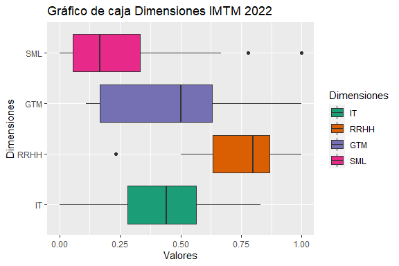

```r
# Preparar dataframe
  dif_dim <- cbind(cuestionarios[1:3], stack(cuestionarios[18:21]))
  dif_dim <- rename(dif_dim, Valores = values, Dimensiones = ind)
  qplot(data = dif_dim, y = Dimensiones, x = Valores, fill = Dimensiones,
      geom = "boxplot", main = "Gráfico de caja Dimensiones IMTM 2022") +
      scale_fill_brewer(palette = "Dark2")
```

# Objetivo 3:

Para *Comparar la madurez digital entre los municipios de la región del Biobio al año 2022* se realizará un gráfico de puntos Cleveland, ademas de presentar los resultados de las variables.

## Gráficos Cleveland de puntos agrupados por Provincia

```r
# Preparar dataframe para Gráfico Cleveland de puntos IMTM agrupado por Provincia
  plot <- select(cuestionarios, Provincia, Municipio, IMTM_2022, IT, RRHH, GTM, SML)
# Poner los nombres, ordenarlos primero por provincia y luego por IMTM
  nameorder <- plot$Municipio[order(plot$Provincia, plot$IMTM_2022)]
# Convertir nombres en factor, con niveles en el orden de nameorder
  plot$Municipio <- factor(plot$Municipio, levels = nameorder)
```

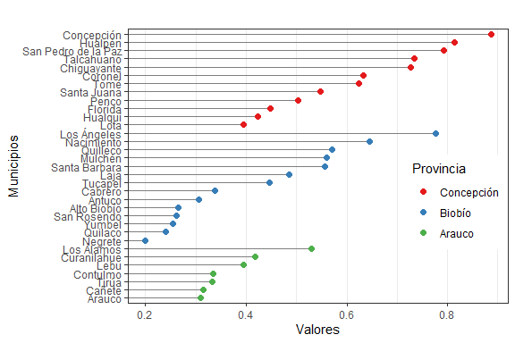

```r
# Realizar gráfico cleaveland IMTM
  ggplot(plot, aes(x = IMTM_2022, y = Municipio)) +
    geom_segment(aes(yend = Municipio), xend = 0, colour = "grey50") +
    geom_point(size = 2, aes(colour = Provincia)) + labs(title = "",
      y = "Municipios", x = "Valores" ) + scale_colour_brewer(palette = "Set1", limits =                    c("Concepción", "Biobío", "Arauco")) + theme_bw() + theme(panel.grid.major.y =
      element_blank(), legend.position = c(0.99, 0.3), legend.justification = c(0.99, 0.3))
```

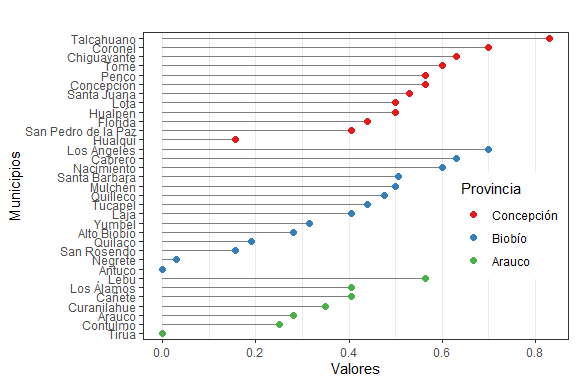

```r
# Realizar gráfica cleaveland IT
  nameorder <- plot$Municipio[order(plot$Provincia, plot$IT)]
  plot$Municipio <- factor(plot$Municipio, levels = nameorder)

  ggplot(plot, aes(x = IT, y = Municipio)) +
    geom_segment(aes(yend = Municipio), xend = 0, colour = "grey50") +
    geom_point(size = 2, aes(colour = Provincia)) + labs(title = "",
       y = "Municipios", x = "Valores" ) + scale_colour_brewer(palette = "Set1", limits =                    c("Concepción", "Biobío", "Arauco")) + theme_bw() + theme(panel.grid.major.y =
       element_blank(), legend.position = c(0.99, 0.3), legend.justification = c(0.99, 0.3))
```

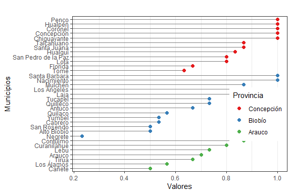

```r
# Realizar gráfico cleaveland RRHH
  nameorder <- plot$Municipio[order(plot$Provincia, plot$RRHH)]
  plot$Municipio <- factor(plot$Municipio, levels = nameorder)

  ggplot(plot, aes(x = RRHH, y = Municipio)) +
    geom_segment(aes(yend = Municipio), xend = 0, colour = "grey50") +
    geom_point(size = 2, aes(colour = Provincia)) + labs(title = "",
       y = "Municipios", x = "Valores" ) + scale_colour_brewer(palette = "Set1", limits =                    c("Concepción", "Biobío", "Arauco")) + theme_bw() + theme(panel.grid.major.y =
       element_blank(), legend.position = c(0.99, 0.3), legend.justification = c(0.99, 0.3))
```

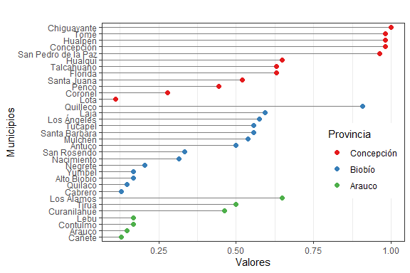

```r
# Realizar gráfico cleaveland GTM
  nameorder <- plot$Municipio[order(plot$Provincia, plot$GTM)]
  plot$Municipio <- factor(plot$Municipio, levels = nameorder)

  ggplot(plot, aes(x = GTM, y = Municipio)) +
    geom_segment(aes(yend = Municipio), xend = 0, colour = "grey50") +
    geom_point(size = 2, aes(colour = Provincia)) + labs(title = "",
       y = "Municipios", x = "Valores" ) + scale_colour_brewer(palette = "Set1", limits =                    c("Concepción", "Biobío", "Arauco")) + theme_bw() + theme(panel.grid.major.y =
       element_blank(), legend.position = c(0.99, 0.3), legend.justification = c(0.99, 0.3))
```

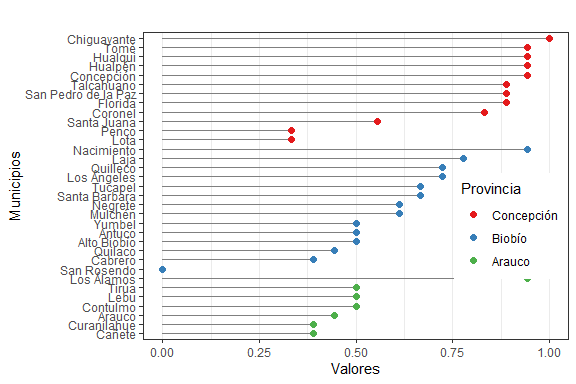

```r
# Realizar gráfico cleaveland procesos
  plot_prc <- select(cuestionarios, Provincia, Municipio, procesos)
  nameorder <- plot_prc$Municipio[order(plot_prc$Provincia, plot_prc$procesos)]
  plot_prc$Municipio <- factor(plot_prc$Municipio, levels = nameorder)

  ggplot(plot_prc, aes(x = procesos, y = Municipio)) +
    geom_segment(aes(yend = Municipio), xend = 0, colour = "grey50") +
    geom_point(size = 2, aes(colour = Provincia)) + labs(title = "",
       y = "Municipios", x = "Valores" ) + scale_colour_brewer(palette = "Set1", limits =                    c("Concepción", "Biobío", "Arauco")) + theme_bw() + theme(panel.grid.major.y =
       element_blank(), legend.position = c(0.99, 0.3), legend.justification = c(0.99, 0.3))
```

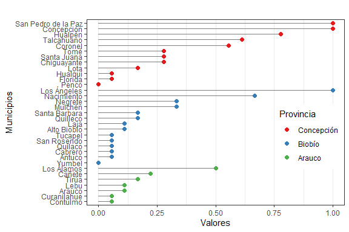

```r
# Realizar gráfico cleaveland SML
  nameorder <- plot$Municipio[order(plot$Provincia, plot$SML)]
  plot$Municipio <- factor(plot$Municipio, levels = nameorder)

  ggplot(plot, aes(x = SML, y = Municipio)) +
    geom_segment(aes(yend = Municipio), xend = 0, colour = "grey50") +
    geom_point(size = 2, aes(colour = Provincia)) + labs(title = "",
       y = "Municipios", x = "Valores" ) + scale_colour_brewer(palette = "Set1", limits =                    c("Concepción", "Biobío", "Arauco")) + theme_bw() + theme(panel.grid.major.y =
       element_blank(), legend.position = c(0.99, 0.3), legend.justification = c(0.99, 0.3))
```

## Resultados IT

```r
# seg_info datos
  Total_seg_info <- colSums(medidas_seguridad[ , 4:7], na.rm = TRUE)
  txt_seg_info <- c("Antivirus", "Antispam", "Firewall", "Autentificación y Criptografia")
# Preparar dataframe
  lista_seg_info <- c(1:4)
  lista_seg_info <- factor(lista_seg_info)
  Total_seg_info <- data.frame(lista_seg_info, txt_seg_info, Total_seg_info)
  Total_seg_info <- mutate(Total_seg_info, no_seg_info = (33-Total_seg_info))
  row.names(Total_seg_info) <- NULL
# Crear tabla
  kable(Total_seg_info, caption = "Total de medidas de seguridad", align= 'r',
        col.names = c("Num", "Medidas de seguridad", "Total", "Faltantes"))
```

Total de medidas de seguridad

| Num | Medidas de seguridad | Total | Faltantes |
| --- | --- | --- | --- |
| 1 | Antivirus | 28 | 5 |
| 2 | Antispam | 19 | 14 |
| 3 | Firewall | 27 | 6 |
| 4 | Autentificación y Criptografia | 19 | 14 |

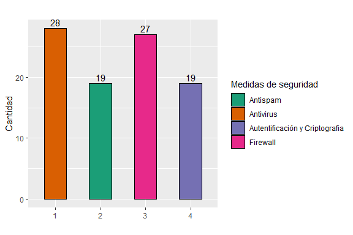

```r
# seg_info gráfico
  ggplot(Total_seg_info, aes(x = lista_seg_info, y = Total_seg_info)) +
  geom_col(aes(fill = txt_seg_info), colour = "black", position = "dodge",
      width = 0.5) + scale_x_discrete("") + scale_y_continuous("Cantidad") +
      labs(title = "") + geom_text(aes(label = Total_seg_info), vjust = -0.3) +
  scale_fill_brewer(palette = "Dark2") + guides(fill=guide_legend(title="Medidas de seguridad"))
```

```r
# num_serv datos
  cant_serv <- c("Ninguno", "Uno", "Dos", "Tres", "Cuatro", "Seis", "Diez")
  total_serv <- medidas_seguridad %>% count(cant_serv)
  total_serv <- total_serv$n # Elim
  Total_num_serv <- data.frame(cant_serv, total_serv)
  row.names(Total_num_serv) <- NULL
```

```r
  kable(Total_num_serv, caption = "Cantidad de servidores", align= 'r',
      col.names = c("Cantidad", "Total"))
```

Cantidad de servidores

| Cantidad | Total |
| --- | --- |
| Ninguno | 6 |
| Uno | 9 |
| Dos | 8 |
| Tres | 4 |
| Cuatro | 3 |
| Seis | 2 |
| Diez | 1 |

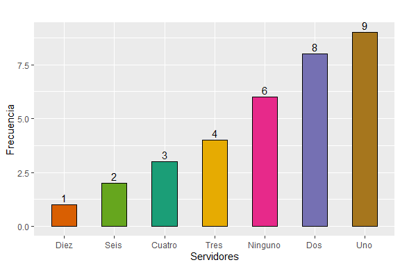

```r
# num_serv gráfico
  ggplot(Total_num_serv, aes(x = fct_reorder(cant_serv, total_serv), y = total_serv)) +
  geom_col(aes(fill = cant_serv), colour = "black", position = "dodge",
      width = 0.5) + scale_x_discrete("Servidores") + scale_y_continuous("Frecuencia") +
      labs(title = "") + geom_text(aes(label = total_serv), vjust = -0.3) +
      scale_fill_brewer(palette = "Dark2")   + guides(fill = "none")
```

## Resultados RRHH

```r
# area_info datos
  si_no <- c("No", "Si")
  total_area_info <- RRHH %>% count(area_info)
  total_area_info <- total_area_info$n
  Total_area_info <- data.frame(si_no, total_area_info)
  row.names(Total_area_info) <- NULL

  kable(Total_area_info, caption = "Presencia de área informática municipal",
        align= 'r', col.names = c("Presencia", "Total"))
```

Presencia de área informática municipal

| Presencia | Total |
| --- | --- |
| No | 9 |
| Si | 24 |

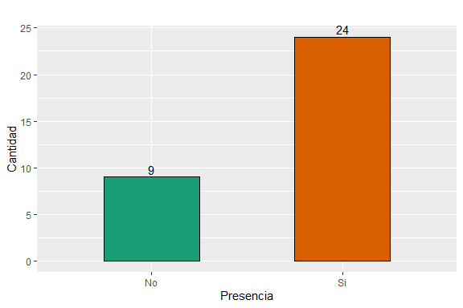

```r
# area_info gráfico
  ggplot(Total_area_info, aes(x = si_no, y = total_area_info)) +
  geom_col(aes(fill = si_no), colour = "black", position = "dodge", width = 0.5) +
  scale_x_discrete("Presencia") + scale_y_continuous("Cantidad") +
        labs(title = "") + geom_text(aes(label = total_area_info), vjust = -0.3) +
        scale_fill_brewer(palette = "Dark2") + guides(fill = "none")
```

```r
# educ_info datos
  nivel_ed <- c("Tecnica nivel superior", "Superior pregrado", "Superior postgrado")
  total_educ_info <- cuestionarios %>% count(educ_info_lvl)
  total_educ_info <- total_educ_info$n
  Total_educ_info <- data.frame(nivel_ed, total_educ_info)
  row.names(Total_educ_info) <- NULL

  kable(Total_educ_info, caption = "Nivel educacional encargado informática",
        align= 'r', col.names = c("Nivel", "Total"))
```

Nivel educacional encargado informática

| Nivel | Total |
| --- | --- |
| Tecnica nivel superior | 11 |
| Superior pregrado | 19 |
| Superior postgrado | 3 |

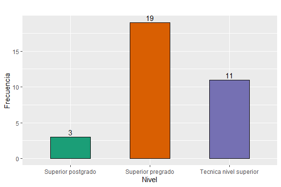

```r
# educ_info gráfico
  ggplot(Total_educ_info, aes(x = nivel_ed, y = total_educ_info)) +
  geom_col(aes(fill = nivel_ed), colour = "black", position = "dodge",
  width = 0.5) + scale_x_discrete("Nivel") + scale_y_continuous("Frecuencia") +
        labs(title = "") + geom_text(aes(label = total_educ_info), vjust = -0.3) +
        scale_fill_brewer(palette = "Dark2") + guides(fill = "none")
```

```r
# org_info datos
  org_info <- c("Alcalde", "Adm. Municipal", "DAF", "SECPLAN", "Secr. Municipal", "Otro")
  total_org_info <- cuestionarios %>% count(org_info_dep)
  total_org_info <- total_org_info$n
  Total_org_info <- data.frame(org_info, total_org_info)
  row.names(Total_org_info) <- NULL
  kable(Total_org_info, caption = "Depencia de la unidad de informática",
        align= 'r', col.names = c("Dependencia", "Total"))
```

Depencia de la unidad de informática

| Dependencia | Total |
| --- | --- |
| Alcalde | 1 |
| Adm. Municipal | 15 |
| DAF | 7 |
| SECPLAN | 4 |
| Secr. Municipal | 4 |
| Otro | 2 |

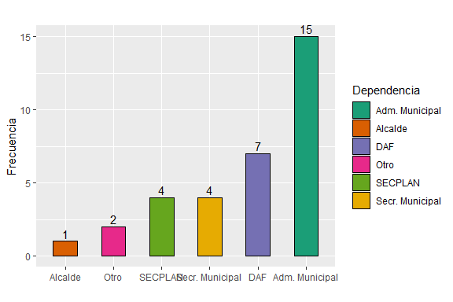

```r
# org_info_gráfico
 ggplot(Total_org_info, aes(x = fct_reorder(org_info, total_org_info), y = total_org_info)) +
  geom_col(aes(fill = org_info), colour = "black", position = "dodge",
  width = 0.5) + scale_x_discrete("") + scale_y_continuous("Frecuencia") +
        labs(title = "") + geom_text(aes(label = total_org_info), vjust = -0.3) +
        scale_fill_brewer(palette = "Dark2") + guides(fill=guide_legend(title="Dependencia"))
```

```r
  # intranet datos
  total_intranet <- cuestionarios %>% count(intranet)
  total_intranet <- total_intranet$n
  Total_intranet <- data.frame(si_no, total_intranet)
  row.names(Total_intranet) <- NULL

  kable(Total_intranet, caption = "Presencia de intranet municipal",
        align= 'r', col.names = c("Presencia", "Total"))
```

Presencia de intranet municipal

| Presencia | Total |
| --- | --- |
| No | 16 |
| Si | 17 |

## Resultados GTM

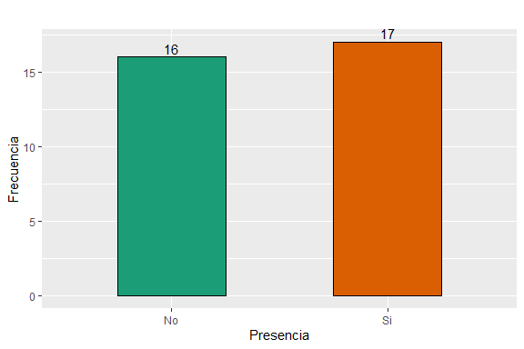

```r
# intranet gráfico
  ggplot(Total_intranet, aes(x = si_no, y = total_intranet)) +
  geom_col(aes(fill = si_no), colour = "black", position = "dodge",
  width = 0.5) + scale_x_discrete("Presencia") + scale_y_continuous("Frecuencia") +
        labs(title = "") + geom_text(aes(label = total_intranet), vjust = -0.3) +
        scale_fill_brewer(palette = "Dark2") + guides(fill = "none")
```

```r
# estrategia_servicios datos
  total_estrategia_s <- cuestionarios %>% count(estrategia_servicios)
  total_estrategia_s <- total_estrategia_s$n
  Total_estrategia_s <- data.frame(si_no, total_estrategia_s)
  row.names(Total_estrategia_s) <- NULL

  kable(Total_estrategia_s, caption = "Presencia de estrategia servicios municipales",
        align= 'r', col.names = c("Presencia", "Total"))
```

Presencia de estrategia servicios municipales

| Presencia | Total |
| --- | --- |
| No | 23 |
| Si | 10 |

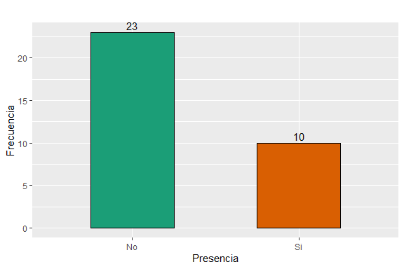

```r
# estrategia_servicios gráfico
  ggplot(Total_estrategia_s, aes(x = si_no, y = total_estrategia_s)) +
  geom_col(aes(fill = si_no), colour = "black", position = "dodge",
  width = 0.5) + scale_x_discrete("Presencia") + scale_y_continuous("Frecuencia") +
        labs(title = "") + geom_text(aes(label = total_estrategia_s), vjust = -0.3) +
        scale_fill_brewer(palette = "Dark2") + guides(fill = "none")
```

```r
# estrategia_gestión datos
  total_estrategia_g <- cuestionarios %>% count(estrategia_gestion)
  total_estrategia_g <- total_estrategia_g$n
  Total_estrategia_g <- data.frame(si_no, total_estrategia_g)
  row.names(Total_estrategia_s) <- NULL

  kable(Total_estrategia_g, caption = "Presencia de estrategia de gestión municipal",
        align= 'r', col.names = c("Presencia", "Total"))
```

Presencia de estrategia de gestión municipal

| Presencia | Total |
| --- | --- |
| No | 22 |
| Si | 11 |

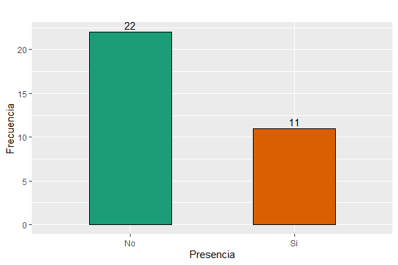

```r
# estrategia_gestion gráfico
  ggplot(Total_estrategia_g, aes(x = si_no, y = total_estrategia_g)) +
  geom_col(aes(fill = si_no), colour = "black", position = "dodge",
  width = 0.5) + scale_x_discrete("Presencia") + scale_y_continuous("Frecuencia") +
        labs(title = "") + geom_text(aes(label = total_estrategia_g), vjust = -0.3) +
        scale_fill_brewer(palette = "Dark2") + guides(fill = "none")
```

```r
# procesos datos
  T_proc <- colSums(procesos[ , 4:21], na.rm = TRUE) #1er paso

  n_proc <- c("Inventario", "Oficina de Partes (Documentos)",
  "Aseo y Ornato (Parques y Jardines)", "Planificación y control presupuestario",
  "Ingreso/egreso Tesorería", "Rentas y Patentes", "Licencias de conducir",
  "Permisos de circulación", "Juzgado de policía local y registro de multas", "Inspección",
  "Administración del cementerio municipal", "Registro Social de hogares",
  "Subsidios (incluye asistencia social y apoyo a la comunidad)", "OMIL (bolsa de empleo)",             "Organizaciones comunitarias", "Dirección de obras municipales (DOM)",
  "Administración de consultorios / farmacias", "Ventanilla única") #2do paso

  l_proc <- c(1:18)
  T_proc <- data.frame(l_proc, n_proc, T_proc) # 3er crear DF

  row.names(T_proc) <- NULL # 4to paso quitar rownames

  kable(T_proc, caption = "Total de procesos", align = 'c',
      col.names = c("Num", "Nombre procesos", "Total"))  # 5to paso crear tabla
```

Total de procesos

| Num | Nombre procesos | Total |
| --- | --- | --- |
| 1 | Inventario | 28 |
| 2 | Oficina de Partes (Documentos) | 25 |
| 3 | Aseo y Ornato (Parques y Jardines) | 7 |
| 4 | Planificación y control presupuestario | 26 |
| 5 | Ingreso/egreso Tesorería | 32 |
| 6 | Rentas y Patentes | 32 |
| 7 | Licencias de conducir | 29 |
| 8 | Permisos de circulación | 31 |
| 9 | Juzgado de policía local y registro de multas | 27 |
| 10 | Inspección | 14 |
| 11 | Administración del cementerio municipal | 14 |
| 12 | Registro Social de hogares | 22 |
| 13 | Subsidios (incluye asistencia social y apoyo a la comunidad) | 19 |
| 14 | OMIL (bolsa de empleo) | 16 |
| 15 | Organizaciones comunitarias | 17 |
| 16 | Dirección de obras municipales (DOM) | 18 |
| 17 | Administración de consultorios / farmacias | 14 |
| 18 | Ventanilla única | 11 |

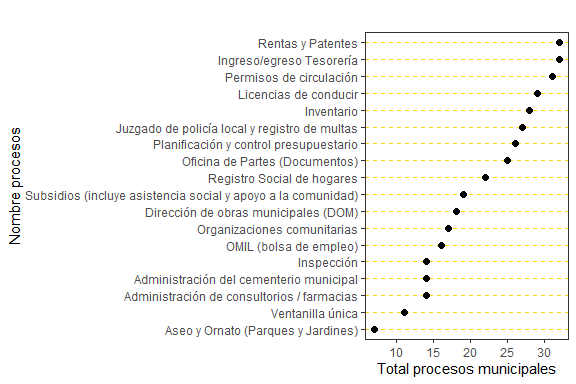

```r
# cleveland procesos
  ggplot(T_proc, aes(x = T_proc, y = reorder(n_proc, T_proc))) +
  geom_point(size = 2) + labs(title = "", y = "Nombre procesos",
                              x = "Total procesos municipales" ) +  theme_bw() +
  theme(panel.grid.major.x = element_blank(), panel.grid.minor.x = element_blank(),
        panel.grid.major.y = element_line(colour = "gold", linetype = "dashed"))
```

## Correlación estrategias y subíndices

```r
  cor_es_t <- cor(cuestionarios$estrategia_servicios, cuestionarios$tramites,
                use = "everything", method=c("pearson"))
  cor_eg_p <- cor(cuestionarios$estrategia_gestion, cuestionarios$procesos,
                use = "everything", method=c("pearson"))

  n_estrategias <- c("Estrategia servicios", "Estrategia gestión")
  n_subindice <- c("Subíndice tramites", "Subíndice procesos")
  valores_correlacion <- c(cor_es_t, cor_eg_p)

  cor_estrategias <- data.frame(n_estrategias, n_subindice, valores_correlacion)

  kable(cor_estrategias, digits = 3, align = 'c', caption =
        "Correlación entre estrategias y subíndices",
      col.names = c("Estrategias", "Subíndices", "Correlación"))
```

Correlación entre estrategias y subíndices

| Estrategias | Subíndices | Correlación |
| --- | --- | --- |
| Estrategia servicios | Subíndice tramites | 0.299 |
| Estrategia gestión | Subíndice procesos | 0.556 |

## Resultados SML

```r
  T_tramite <- colSums(tramites[ , 4:26], na.rm = TRUE)
  n_tramite <- c("Obtención de Patente comercial",
  "Renovación de la Patente comercial", "Pago de la Patente comercial",
  "Obtención de la Patente industrial", "Renovación de la Patente industrial",
  "Obtención de Patente de alcoholes", "Renovación de la Patente de alcoholes",
  "Pago de la Patente de alcoholes", "Certificado de no expropiación",
  "Permiso de demolición", "Obtención de Permiso de edificación",
  "Renovación de Permiso de edificación", "Pago de Permiso de edificación",
  "Permiso de uso de bienes nacionales de uso público", "Informe de zonificación",
  "Recepción de obra", "Certificado de informaciones previas", "Permiso de circulación",
  "Pago de multas en Juzgado de policía local", "Solicitud de corte y poda de árboles",
  "Solicitud de cambio de domicilio", "Obtención de Patente comercial", "Otro")

  l_tramite <- c(1:23)
  T_tramites <- data.frame(l_tramite, n_tramite, T_tramite)
  row.names(T_tramites) <- NULL

  kable(T_tramites, caption = "Total de trámites", align= 'r', col.names =
        c("Num", "Nombre trámites", "Total"))
```

Total de trámites

| Num | Nombre trámites | Total |
| --- | --- | --- |
| 1 | Obtención de Patente comercial | 6 |
| 2 | Renovación de la Patente comercial | 8 |
| 3 | Pago de la Patente comercial | 16 |
| 4 | Obtención de la Patente industrial | 4 |
| 5 | Renovación de la Patente industrial | 5 |
| 6 | Obtención de Patente de alcoholes | 3 |
| 7 | Renovación de la Patente de alcoholes | 5 |
| 8 | Pago de la Patente de alcoholes | 10 |
| 9 | Certificado de no expropiación | 8 |
| 10 | Permiso de demolición | 8 |
| 11 | Obtención de Permiso de edificación | 8 |
| 12 | Renovación de Permiso de edificación | 6 |
| 13 | Pago de Permiso de edificación | 8 |
| 14 | Permiso de uso de bienes nacionales de uso público | 5 |
| 15 | Informe de zonificación | 7 |
| 16 | Recepción de obra | 7 |
| 17 | Certificado de informaciones previas | 7 |
| 18 | Permiso de circulación | 29 |
| 19 | Pago de multas en Juzgado de policía local | 9 |
| 20 | Solicitud de corte y poda de árboles | 3 |
| 21 | Solicitud de cambio de domicilio | 3 |
| 22 | Obtención de Patente comercial | 4 |
| 23 | Otro | 7 |

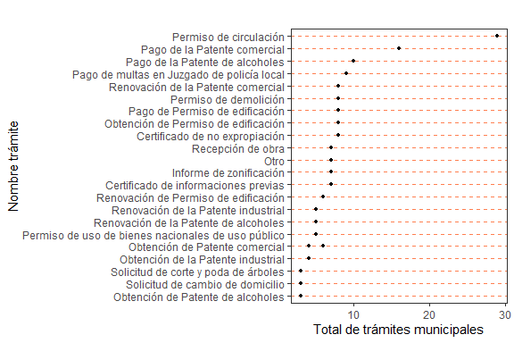

```r
  ggplot(T_tramites, aes(x = T_tramite, y = reorder(n_tramite, T_tramite))) +
  geom_point(size = 1) + labs(title = "", y = "Nombre trámite",
                              x = "Total de trámites municipales" ) +  theme_bw() +
  theme(panel.grid.major.x = element_blank(), panel.grid.minor.x = element_blank(),
        panel.grid.major.y = element_line(colour = "coral", linetype = "dashed"))
```

# Objetivo 4:

Para *Categorizar según FIGEM y Provincia* se filtrará el Dataframe y se realizará estadística descriptiva, también gráficos de caja.

```r
  FIGEM_1 <- filter(cuestionarios, FIGEM== 1)
  FIGEM_2 <- filter(cuestionarios, FIGEM== 2)
  FIGEM_3 <- filter(cuestionarios, FIGEM== 3)
  FIGEM_4 <- filter(cuestionarios, FIGEM== 4)
  FIGEM_5 <- filter(cuestionarios, FIGEM== 5)

  Provincia_conce <- filter(cuestionarios, Provincia== "Concepción")
  Provincia_biobio <- filter(cuestionarios, Provincia== "Biobío")
  Provincia_arauco <- filter(cuestionarios, Provincia== "Arauco")
```

## Estadística descriptiva FIGEM

```r
  Descr_F1 <- stats_descr(FIGEM_1$IMTM_2022)
  Descr_F2 <- stats_descr(FIGEM_2$IMTM_2022)
  Descr_F3 <- stats_descr(FIGEM_3$IMTM_2022)
  Descr_F4 <- stats_descr(FIGEM_4$IMTM_2022)
  Descr_F5 <- stats_descr(FIGEM_5$IMTM_2022)

  Categorizar_F <- data.frame(Descr_F1, Descr_F2, Descr_F3, Descr_F4, Descr_F5)

  kable(Categorizar_F, digits = 2, align = 'r', caption =
          "Estadística descriptiva IMTM 2022 por FIGEM",
          col.names = c("1", "2", "3","4", "5"))
```

Estadística descriptiva IMTM 2022 por FIGEM

|  | 1 | 2 | 3 | 4 | 5 |
| --- | --- | --- | --- | --- | --- |
| Mínimo | 0.73 | 0.39 | 0.26 | 0.31 | 0.20 |
| Primer_Cuartil.25% | 0.73 | 0.50 | 0.34 | 0.35 | 0.26 |
| Media | 0.79 | 0.59 | 0.45 | 0.40 | 0.36 |
| Máximo | 0.89 | 0.78 | 0.65 | 0.49 | 0.57 |
| Mediana | 0.79 | 0.62 | 0.42 | 0.40 | 0.33 |
| Variación | 0.00 | 0.02 | 0.02 | 0.02 | 0.01 |
| Desviación_estandar | 0.07 | 0.14 | 0.13 | 0.12 | 0.12 |
| Tercer_Cuartil.75% | 0.81 | 0.63 | 0.56 | 0.44 | 0.45 |
| Rango | 0.16 | 0.38 | 0.38 | 0.18 | 0.37 |
| Rango_Intercuartil.75% | 0.08 | 0.13 | 0.22 | 0.09 | 0.18 |
| Asimetria | 0.32 | -0.03 | 0.06 | 0.00 | 0.35 |
| Curtosis | -1.77 | -1.75 | -1.69 | -2.75 | -1.38 |

## Boxplot IMTM 2022 según FIGEM

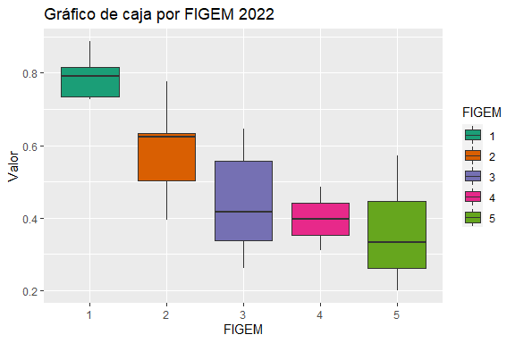

```r
  cuestionarios$FIGEM <- factor(cuestionarios$FIGEM)
  qplot(data = cuestionarios, x = FIGEM, y = IMTM_2022, fill = FIGEM,
      geom = "boxplot", ylab = "Valor", main = "Gráfico de caja por FIGEM 2022") +
      scale_fill_brewer(palette = "Dark2")
```

## Boxplot IMTM 2015 según FIGEM

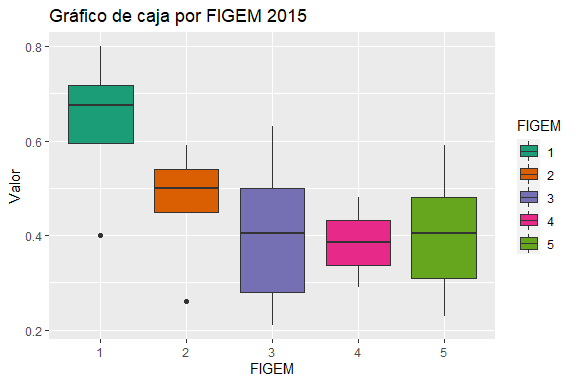

```r
  IMTM_2015$FIGEM <- factor(IMTM_2015$FIGEM)
  qplot(data = IMTM_2015, x = FIGEM, y = IMTM_2015, fill = FIGEM,
      geom = "boxplot", ylab = "Valor", main = "Gráfico de caja por FIGEM 2015") +
      scale_fill_brewer(palette = "Dark2")
```

## Estadística descriptiva Provincia

```r
  Descr_Concepcion <- stats_descr(Provincia_conce$IMTM_2022)
  Descr_Biobio     <- stats_descr(Provincia_biobio$IMTM_2022)
  Descr_Arauco     <- stats_descr(Provincia_arauco$IMTM_2022)

  Categorizar_P <- data.frame(Descr_Concepcion, Descr_Biobio, Descr_Arauco)

  kable(Categorizar_P, digits = 2, align = 'r', caption =
          "Estadística descriptiva IMTM 2022 por provincia",
          col.names = c("Concepción", "Biobío", "Arauco"))
```

Estadística descriptiva IMTM 2022 por provincia

|  | Concepción | Biobío | Arauco |
| --- | --- | --- | --- |
| Mínimo | 0.39 | 0.20 | 0.31 |
| Primer_Cuartil.25% | 0.49 | 0.26 | 0.32 |
| Media | 0.63 | 0.42 | 0.38 |
| Máximo | 0.89 | 0.78 | 0.53 |
| Mediana | 0.63 | 0.39 | 0.33 |
| Variación | 0.03 | 0.03 | 0.01 |
| Desviación_estandar | 0.17 | 0.18 | 0.08 |
| Tercer_Cuartil.75% | 0.75 | 0.56 | 0.41 |
| Rango | 0.49 | 0.58 | 0.22 |
| Rango_Intercuartil.75% | 0.26 | 0.30 | 0.08 |
| Asimetria | 0.03 | 0.40 | 0.88 |
| Curtosis | -1.58 | -1.27 | -0.79 |

## Boxplot IMTM 2022 según provincia

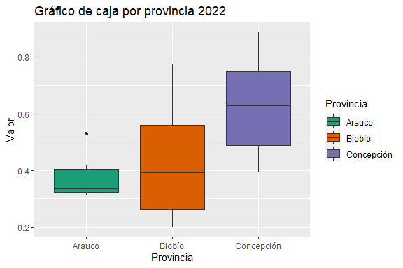

```r
  cuestionarios$Provincia <- factor(cuestionarios$Provincia)
  qplot(data = cuestionarios, x = Provincia, y = IMTM_2022, fill = Provincia,
      geom = "boxplot", ylab = "Valor", main = "Gráfico de caja por provincia 2022") +
    scale_fill_brewer(palette = "Dark2")
```

## Boxplot IMTM 2015 según provincia

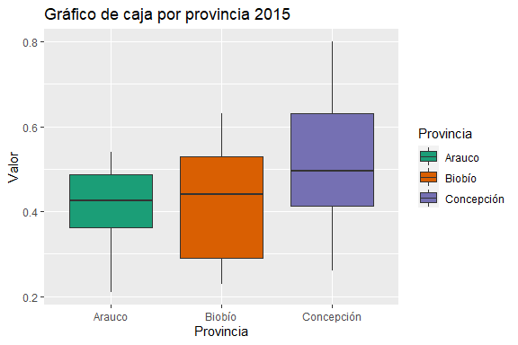

```r
  IMTM_2015$Provincia <- factor(IMTM_2015$Provincia)
  qplot(data = IMTM_2015, x = Provincia, y = IMTM_2015, fill = Provincia,
      geom = "boxplot", ylab = "Valor", main = "Gráfico de caja por provincia 2015") +
    scale_fill_brewer(palette = "Dark2")
```